# PA 5 Midterm

Eileen Blum

April 3, 2018

## Load Data

```r
library(tidyverse)
pa5_data <- read_csv("./data_raw/lang_data_raw.csv")
head(pa5_data)
```

```
## # A tibble: 6 x 4
##   id                  iq motivation  prof
##   <chr>            <dbl>      <dbl> <dbl>
## 1 p01_male_older    97.0       1.47 0.670
## 2 p02_female_older  91.5       1.31 0.460
## 3 p03_male_older    97.2       1.48 0.550
## 4 p04_female_older  91.5       1.31 0.490
## 5 p05_male_older    96.0       1.44 0.590
## 6 p06_female_older  93.8       1.37 0.620
```

## Tidy Data

I used the *separate()* function to move participant identifiers into separate columns so each participant has only a number id and there is a separate column for gender, age, iq, language aptitude, and proficiency.

```r
pa5_tidy <- pa5_data %>% #rename the tidy dataset
  separate(., col = id, into = c('id', 'gender', 'age'), sep = "_") #separate columns
head(pa5_tidy) #view first 6 lines of resulting tidy data set
```

```
## # A tibble: 6 x 6
##   id    gender age      iq motivation  prof
##   <chr> <chr>  <chr> <dbl>      <dbl> <dbl>
## 1 p01   male   older  97.0       1.47 0.670
## 2 p02   female older  91.5       1.31 0.460
## 3 p03   male   older  97.2       1.48 0.550
## 4 p04   female older  91.5       1.31 0.490
## 5 p05   male   older  96.0       1.44 0.590
## 6 p06   female older  93.8       1.37 0.620
```

## Composite Score

I used the *mutate()* function to create a new column with the composite aptitude scores.

```r
pa5_comp <- pa5_tidy %>%
 mutate(., composite_score = (log(iq / 80) + log(motivation))) #create new column with composite score using mutate() (https://www.jvcasillas.com/ru_teaching/ru_spanish_589/589_01_s2018/slides/05_lm/05_model_tuning/index.html#50)
head(pa5_comp) #view first 6 lines
```

```
## # A tibble: 6 x 7
##   id    gender age      iq motivation  prof composite_score
##   <chr> <chr>  <chr> <dbl>      <dbl> <dbl>           <dbl>
## 1 p01   male   older  97.0       1.47 0.670           0.578
## 2 p02   female older  91.5       1.31 0.460           0.404
## 3 p03   male   older  97.2       1.48 0.550           0.587
## 4 p04   female older  91.5       1.31 0.490           0.404
## 5 p05   male   older  96.0       1.44 0.590           0.547
## 6 p06   female older  93.8       1.37 0.620           0.474
```

## Descriptive Statistics

```r
pa5_stat <- pa5_comp %>%
  select(., -id, -gender, -age)
  summary(pa5_stat)
```

```
##        iq           motivation         prof        composite_score
##  Min.   : 85.54   Min.   :1.140   Min.   :0.1700   Min.   :0.1980
##  1st Qu.: 92.64   1st Qu.:1.337   1st Qu.:0.5000   1st Qu.:0.4375
##  Median : 94.44   Median :1.390   Median :0.6000   Median :0.4953
##  Mean   : 94.35   Mean   :1.393   Mean   :0.6020   Mean   :0.4932
##  3rd Qu.: 96.36   3rd Qu.:1.450   3rd Qu.:0.6925   3rd Qu.:0.5577
##  Max.   :101.17   Max.   :1.600   Max.   :0.9800   Max.   :0.7048
```

## Plot

Proficiency scores appear to increase as composite scores increase regardless of age. Older subjects had equally high and low composite scores as younger subjects, but the lowest proficiency scores of older subjects were much lower than the lowest proficiency scores of younger subjects. Likewise, the highest proficiency scores of younger subjects were higher than the highest proficiency scores of older subjects. It also appears to be the case that older subjects’ proficiency increased as a function of composite score at a faster rate than the proficiency of younger subjects.

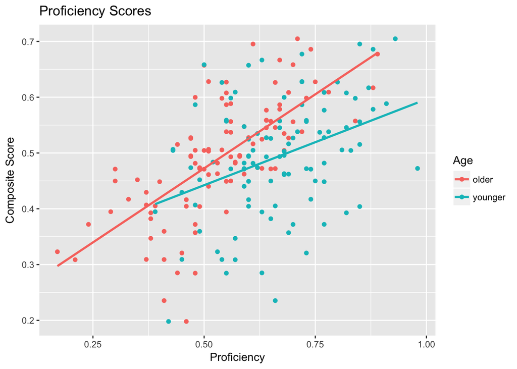

```r
pa5_comp %>%
  ggplot(., aes(x = prof, y = composite_score, color = age)) +
  labs(x = "Proficiency", y = "Composite Score", color = "Age", title = "Proficiency Scores") +
  geom_point() +
  geom_smooth(method = lm, se = FALSE)
```

## Fit a Model

```r
pa5_mod <- lm(prof ~ age * composite_score, data = pa5_comp)
summary(pa5_mod) #tests main effects of younger age, composite score,  and the interaction between the two
```

```
##
## Call:
## lm(formula = prof ~ age * composite_score, data = pa5_comp)
##
## Residuals:
##      Min       1Q   Median       3Q      Max
## -0.24110 -0.06781  0.00171  0.07496  0.32423
##
## Coefficients:
##                            Estimate Std. Error t value Pr(>|t|)
## (Intercept)                 0.08963    0.05266   1.702   0.0903 .
## ageyounger                  0.35436    0.07447   4.758 3.78e-06 ***
## composite_score             0.91121    0.10447   8.722 1.17e-15 ***
## ageyounger:composite_score -0.46286    0.14775  -3.133   0.0020 **
## ---
## Signif. codes:  0 '***' 0.001 '**' 0.01 '*' 0.05 '.' 0.1 ' ' 1
##
## Residual standard error: 0.1089 on 196 degrees of freedom
## Multiple R-squared:  0.4518, Adjusted R-squared:  0.4434
## F-statistic: 53.85 on 3 and 196 DF,  p-value: < 2.2e-16
```

The interaction between age and composite score was shown to be a significant predictor of proficiency for both older and younger participants (F(2) = 62.58 and p < 0.001).

```r
pa5_modint <- lm(prof ~ age:composite_score, data = pa5_comp)
summary(pa5_modint) #tests interactions between composite score and age for both older and younger participants
```

```
##
## Call:
## lm(formula = prof ~ age:composite_score, data = pa5_comp)
##
## Residuals:
##      Min       1Q   Median       3Q      Max
## -0.28836 -0.06186  0.01013  0.07080  0.33896
##
## Coefficients:
##                            Estimate Std. Error t value Pr(>|t|)
## (Intercept)                 0.26682    0.03923   6.802 1.21e-10 ***
## ageolder:composite_score    0.56729    0.07947   7.138 1.77e-11 ***
## ageyounger:composite_score  0.79226    0.07947   9.969  < 2e-16 ***
## ---
## Signif. codes:  0 '***' 0.001 '**' 0.01 '*' 0.05 '.' 0.1 ' ' 1
##
## Residual standard error: 0.1147 on 197 degrees of freedom
## Multiple R-squared:  0.3885, Adjusted R-squared:  0.3823
## F-statistic: 62.58 on 2 and 197 DF,  p-value: < 2.2e-16
```

## Model diagnostics

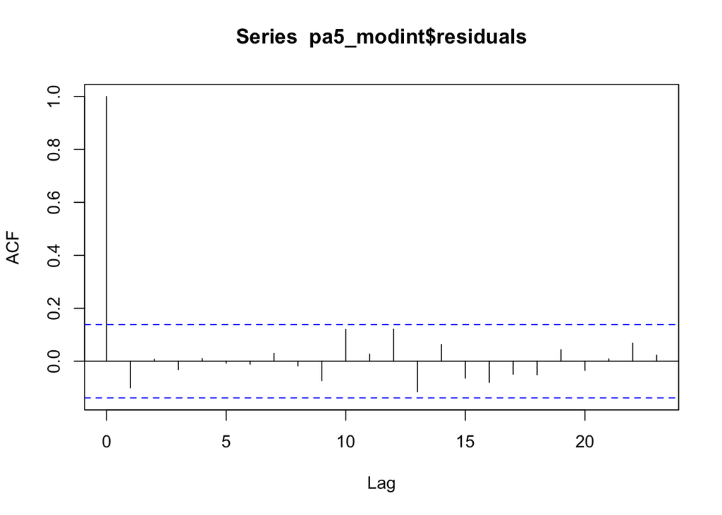

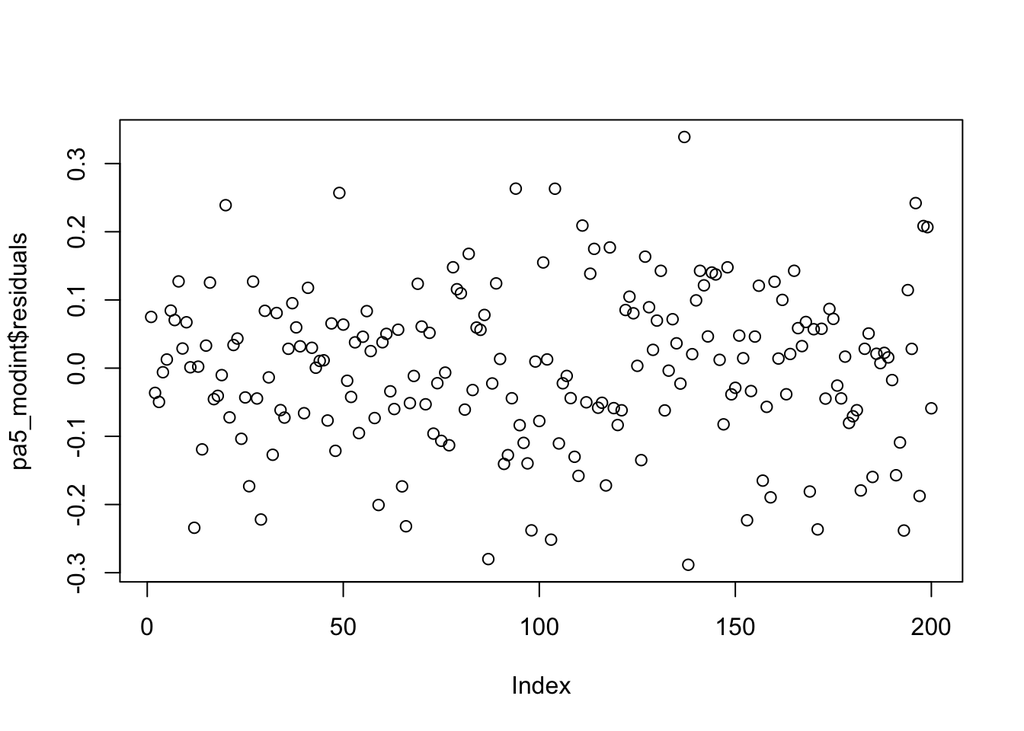